# 数据可视化

# 目录

- 1 前提准备
- 2 初识`ggplot2`
  - 2.1 `mpg` 数据集
  - 2.2 绘制一幅 `ggplot`
  - 2.3 `ggplot2` 绘图模板
- 3 映射图形属性（`aesthetic`）
  - 3.1 用 `aes()` 连接图形属性与变量名
  - 3.2 人工设置图形属性
- 4 分面
- 5 几何对象
  - 5.1 散点图、smooth图
  - 5.2 在同一分面内，对不同类型的数据分别绘制图形
  - 5.3 在同一分面内，同时绘制多种几何对象
- 6 统计变换
  - 6.1 条形图 - geom_bar
  - 6.2 stat
- 7 位置调整 - position参数
  - 7.1 fill参数
  - 7.2 position参数
- 8 坐标系统
- 9 `ggplot`绘图语法
  - 9.1 语法模板
  - 9.2 绘图流程

# 1 前提准备

```r
library(tidyverse)
```

# 2 初识`ggplot2`

## 2.1 `mpg` 数据集

```r
mpg
```

| manufacturer | model | displ | year | cyl | trans | drv | cty | hwy | fl | class |
| --- | --- | --- | --- | --- | --- | --- | --- | --- | --- | --- |
| audi | a4 | 1.8 | 1999 | 4 | auto(l5) | f | 18 | 29 | p | compact |
| audi | a4 | 1.8 | 1999 | 4 | manual(m5) | f | 21 | 29 | p | compact |
| audi | a4 | 2.0 | 2008 | 4 | manual(m6) | f | 20 | 31 | p | compact |
| audi | a4 | 2.0 | 2008 | 4 | auto(av) | f | 21 | 30 | p | compact |
| audi | a4 | 2.8 | 1999 | 6 | auto(l5) | f | 16 | 26 | p | compact |
| audi | a4 | 2.8 | 1999 | 6 | manual(m5) | f | 18 | 26 | p | compact |
| audi | a4 | 3.1 | 2008 | 6 | auto(av) | f | 18 | 27 | p | compact |
| audi | a4 quattro | 1.8 | 1999 | 4 | manual(m5) | 4 | 18 | 26 | p | compact |
| audi | a4 quattro | 1.8 | 1999 | 4 | auto(l5) | 4 | 16 | 25 | p | compact |
| audi | a4 quattro | 2.0 | 2008 | 4 | manual(m6) | 4 | 20 | 28 | p | compact |

[output cut: 224 more lines]

```
#> # A tibble: 234 × 11
#>   manufacturer model displ  year   cyl      trans   drv   cty   hwy    fl
#>          <chr> <chr> <dbl> <int> <int>      <chr> <chr> <int> <int> <chr>
#> 1         audi    a4   1.8  1999     4   auto(l5)     f    18    29     p
#> 2         audi    a4   1.8  1999     4 manual(m5)     f    21    29     p
#> 3         audi    a4   2.0  2008     4 manual(m6)     f    20    31     p
#> 4         audi    a4   2.0  2008     4   auto(av)     f    21    30     p
#> 5         audi    a4   2.8  1999     6   auto(l5)     f    16    26     p
#> 6         audi    a4   2.8  1999     6 manual(m5)     f    18    26     p
#> # ... with 228 more rows, and 1 more variables: class <chr>
```

- The discrete variables in mpg are: `manufacturer`, `model`, `trans`, `drv`, `fl`, `class`
- The continuous variables in mpg are: `displ`, `year`, `cyl`, `cty`, `hwy`

## 2.2 绘制一幅 `ggplot`

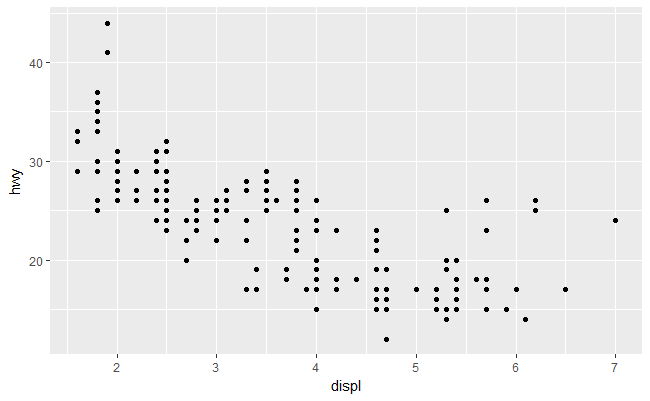

```r
ggplot(data = mpg) +
  geom_point(mapping = aes(x = displ, y = hwy))
```

## 2.3 `ggplot2` 绘图模板

```
ggplot(data = <DATA>) +
  <GEOM_FUNCTION>(mapping = aes(<MAPPINGS>))
```

# 3 映射图形属性（`aesthetic`）

## 3.1 用 `aes()` 连接图形属性与变量名

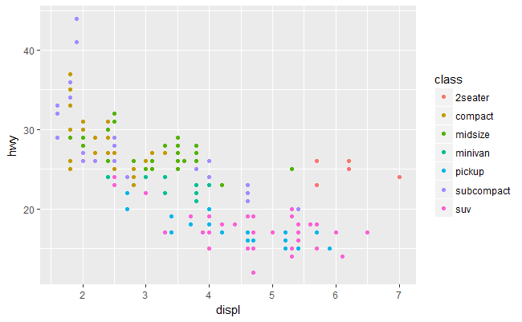

```r
ggplot(data = mpg) +
  geom_point(mapping = aes(x = displ, y = hwy, color = class))
```

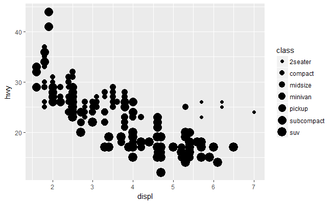

```r
ggplot(data = mpg) +
  geom_point(mapping = aes(x = displ, y = hwy, size = class))
```

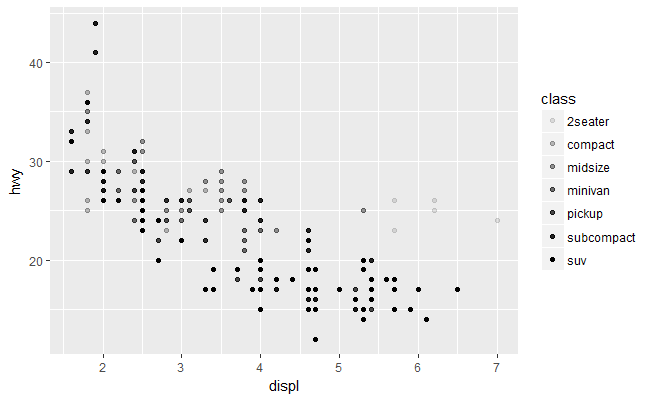

```r
ggplot(data = mpg) +
  geom_point(mapping = aes(x = displ, y = hwy, alpha = class))
```

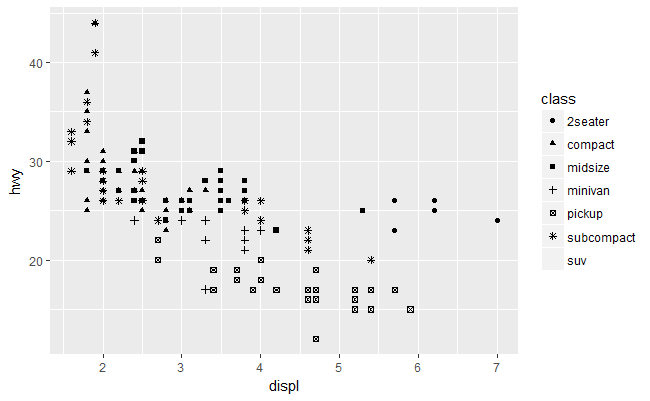

```r
ggplot(data = mpg) +
  geom_point(mapping = aes(x = displ, y = hwy, shape = class))
```

禁用图例

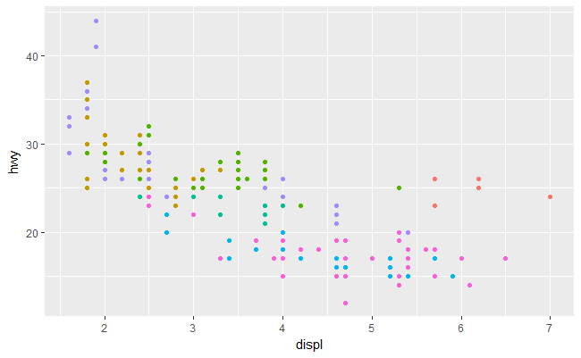

```r
ggplot(data = mpg) +
  geom_point(mapping = aes(x = displ, y = hwy, color = class), show.legend = FALSE)
```

## 3.2 人工设置图形属性

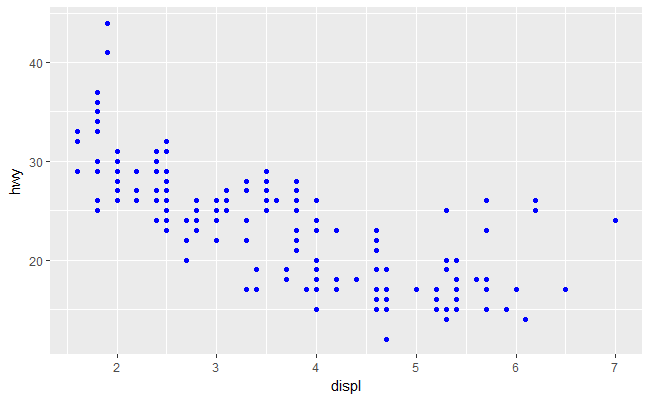

```r
ggplot(data = mpg) +
  geom_point(mapping = aes(x = displ, y = hwy), color = "blue")
```

To set an aesthetic manually, call the aesthetic as an argument of your geom function. Then pass the aesthetic a value that R will recognize, such as

- the name of a color as a character string
- the size of a point as a cex expansion factor (see `?par`)
- the shape as a point as a number code

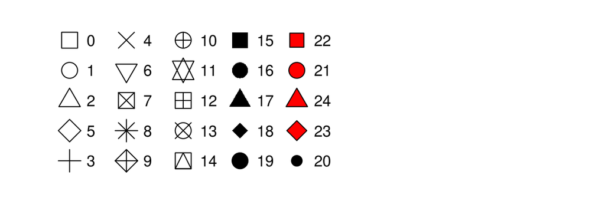

R uses the following numeric codes to refer to the following shapes.

If you get an odd result, double check that you are calling the aesthetic as its own argument (and not calling it from inside of `mapping = aes()`. I like to think of aesthetics like this, if you set the aesthetic:

- inside of the `aes()` function, `ggplot2` will map the aesthetic to data values and build a legend.
- outside of the `aes()` function, `ggplot2` will directly set the aesthetic to your input.

# 4 分面

使用 `facet_wrap()` 来绘制分面，传递给 `facet_wrap()` 的变量必须是离散型变量

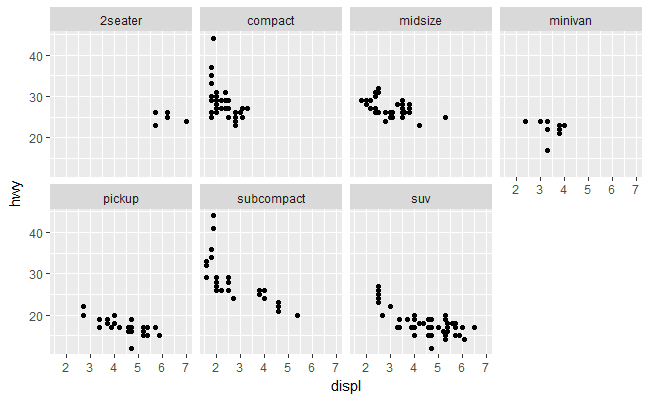

```r
ggplot(data = mpg) +
  geom_point(mapping = aes(x = displ, y = hwy)) +
  facet_wrap(~ class, nrow = 2)
```

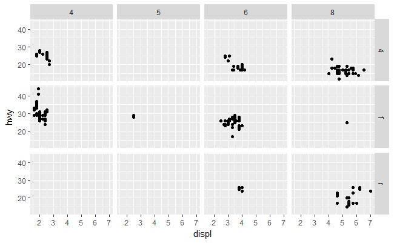

```r
ggplot(data = mpg) +
  geom_point(mapping = aes(x = displ, y = hwy)) +
  facet_grid(drv ~ cyl)
```

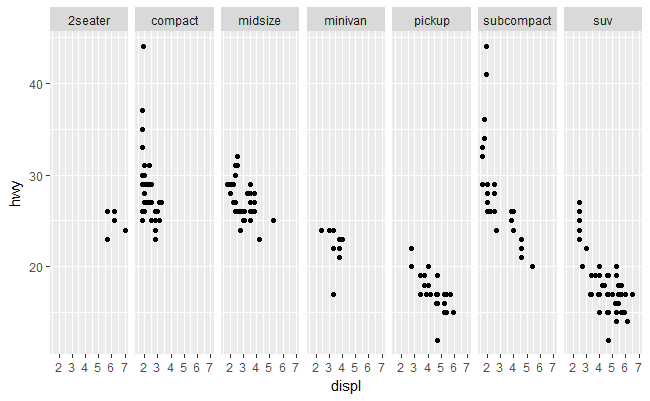

```r
ggplot(data = mpg) +
  geom_point(mapping = aes(x = displ, y = hwy)) +
  facet_grid(. ~ class)
```

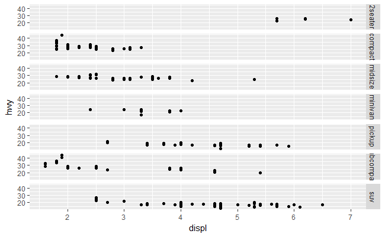

```r
ggplot(data = mpg) +
  geom_point(mapping = aes(x = displ, y = hwy)) +
  facet_grid(class ~ .)
```

# 5 几何对象

## 5.1 散点图、smooth图

散点图 - geom_point

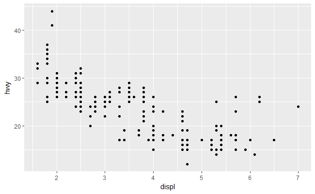

```r
ggplot(data = mpg) +
  geom_point(mapping = aes(x = displ, y = hwy))
```

smooth图 - geom_smooth

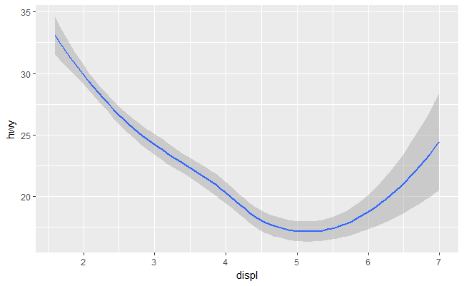

```r
ggplot(data = mpg) +
  geom_smooth(mapping = aes(x = displ, y = hwy))
```

## 5.2 在同一分面内，对不同类型的数据分别绘制图形

linetype - 分别绘制，线型不同

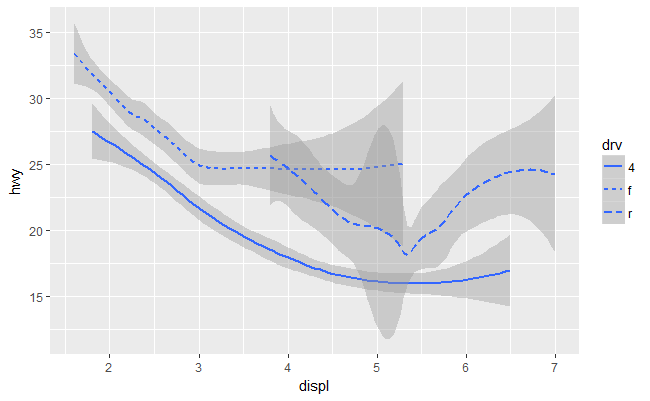

```r
ggplot(data = mpg) +
  geom_smooth(mapping = aes(x = displ, y = hwy, linetype = drv))
```

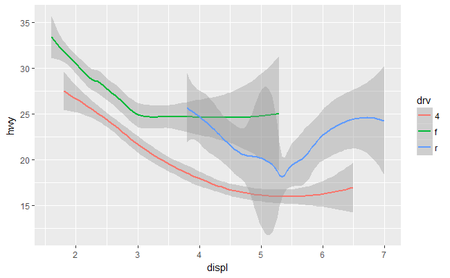

```r
ggplot(data = mpg) +
  geom_smooth(mapping = aes(x = displ, y = hwy, color = drv))
```

group - 分别绘制，图形属性相同

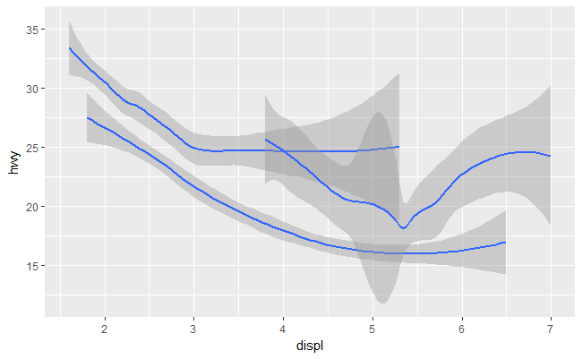

```r
ggplot(data = mpg) +
  geom_smooth(mapping = aes(x = displ, y = hwy, group = drv))
```

## 5.3 在同一分面内，同时绘制多种几何对象

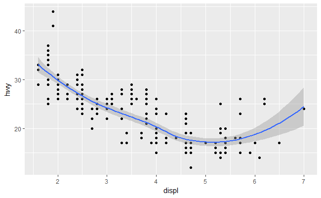

```r
ggplot(data = mpg) +
  geom_point(mapping = aes(x = displ, y = hwy)) +
  geom_smooth(mapping = aes(x = displ, y = hwy))
```

可以将mapping写在ggplot中，不同图层共用图形属性

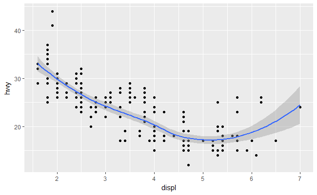

```r
ggplot(data = mpg, mapping = aes(x = displ, y = hwy)) +
  geom_point() +
  geom_smooth()
```

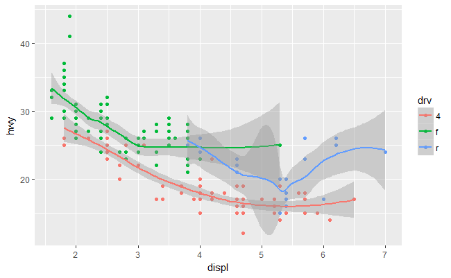

```r
ggplot(data = mpg, mapping = aes(x = displ, y = hwy, color = drv)) +
  geom_point() +
  geom_smooth()
```

对不同的图层，设置不同的图形属性

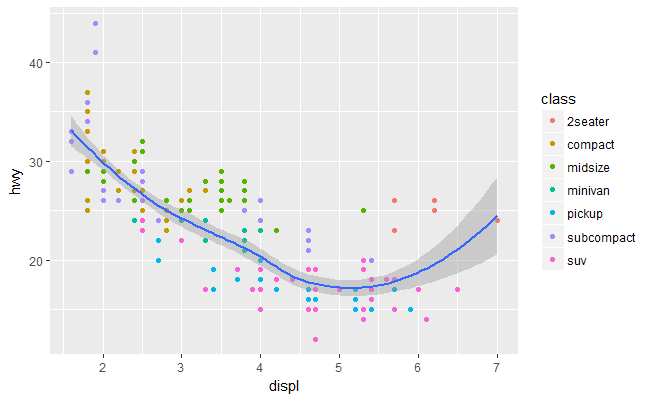

```r
ggplot(data = mpg, mapping = aes(x = displ, y = hwy)) +
  geom_point(mapping = aes(color = class)) +
  geom_smooth()
```

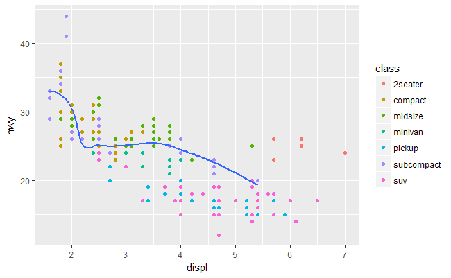

```r
ggplot(data = mpg, mapping = aes(x = displ, y = hwy)) +
  geom_point(mapping = aes(color = class)) +
  geom_smooth(data = filter(mpg, class == "subcompact"), se = FALSE)
```

# 6 统计变换

## 6.1 条形图 - geom_bar

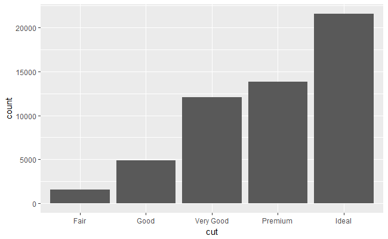

```r
ggplot(data = diamonds) +
  geom_bar(mapping = aes(x = cut))
```

`geom_bar` 的工作原理

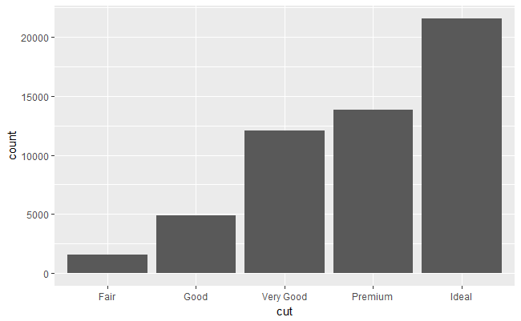

```r
ggplot(data = diamonds) +
  stat_count(mapping = aes(x = cut))
```

## 6.2 stat

会使用到stat的3种情形

- 1 改变默认的stat（默认的stat是count和prop，可以更改为identity）

```r
demo <- tribble(
  ~a,      ~b,
  "bar_1", 20,
  "bar_2", 30,
  "bar_3", 40
)
```

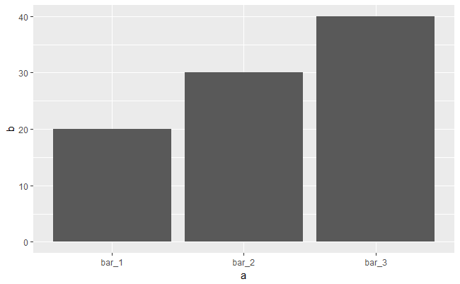

```r
ggplot(data = demo) +
  geom_bar(mapping = aes(x = a, y = b), stat = "identity")
```

- 2 改变变量到图形属性的映射方式（从频数变为比例）

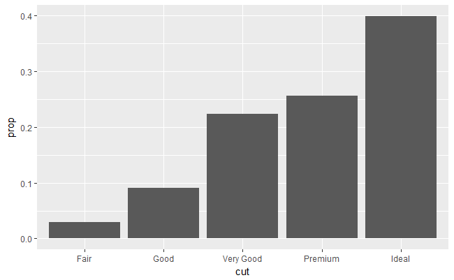

```r
ggplot(data = diamonds) +
  geom_bar(mapping = aes(x = cut, y = ..prop.., group = 1))
```

绘制比例条形图，必须设置 `group = 1`

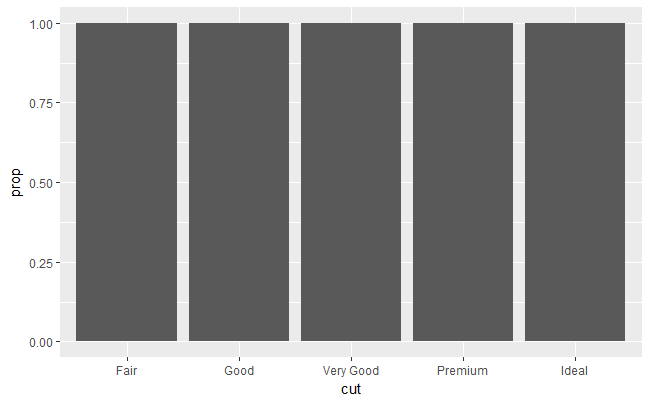

```r
ggplot(data = diamonds) +
  geom_bar(mapping = aes(x = cut, y = ..prop..))
```

- 3 更加直观地观察变量的统计性质

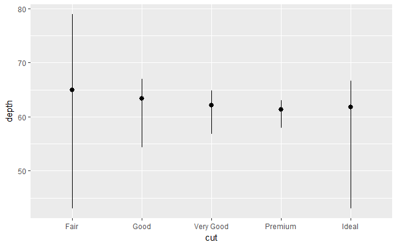

```r
ggplot(data = diamonds) +
  stat_summary(
    mapping = aes(x = cut, y = depth),
    fun.ymin = min,
    fun.ymax = max,
    fun.y = median
  )
```

# 7 位置调整 - position参数

## 7.1 fill参数

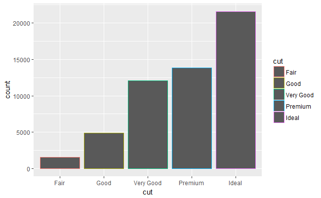

```r
ggplot(data = diamonds) +
  geom_bar(mapping = aes(x = cut, colour = cut))
```

将fill属性映射到与x相同的变量

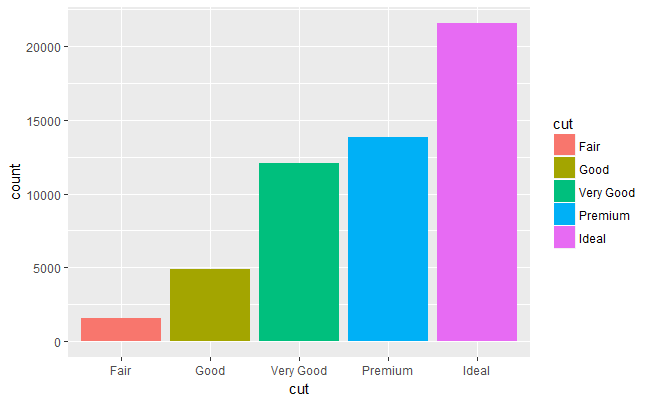

```r
ggplot(data = diamonds) +
  geom_bar(mapping = aes(x = cut, fill = cut))
```

将fill属性映射到另一个变量，自动绘制堆积（stack）条形图

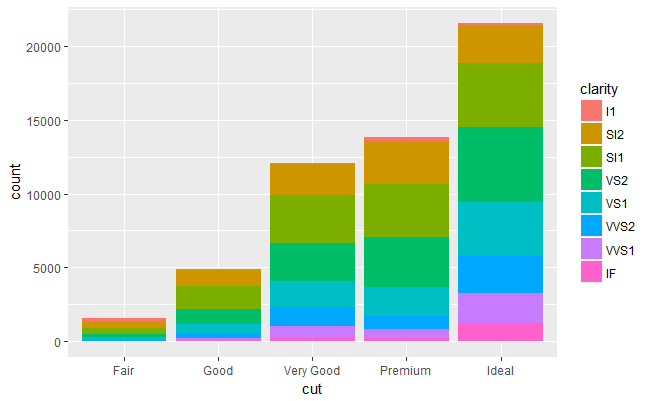

```r
ggplot(data = diamonds) +
  geom_bar(mapping = aes(x = cut, fill = clarity))
```